# sklearn.linear_model.Ridge

**class*sklearn.linear_model.Ridge(*alpha=1.0*, *, *fit_intercept=True*, *normalize='deprecated'*, *copy_X=True*, *max_iter=None*, *tol=0.001*, *solver='auto'*, *positive=False*, *random_state=None*)[[source]](https://github.com/scikit-learn/scikit-learn/blob/f3f51f9b6/sklearn/linear_model/_ridge.py#L910)**

Linear least squares with l2 regularization.

Minimizes the objective function:

```
||y - Xw||^2_2 + alpha * ||w||^2_2
```

This model solves a regression model where the loss function is the linear least squares function and regularization is given by the l2-norm. Also known as Ridge Regression or Tikhonov regularization. This estimator has built-in support for multi-variate regression (i.e., when y is a 2d-array of shape (n_samples, n_targets)).

Read more in the User Guide.

**Parameters:**

**alpha**{float, ndarray of shape (n_targets,)}, default=1.0**

Constant that multiplies the L2 term, controlling regularization strength. `alpha` must be a non-negative float i.e. in `[0, inf)`.

When `alpha = 0`, the objective is equivalent to ordinary least squares, solved by the `LinearRegression` object. For numerical reasons, using `alpha = 0` with the `Ridge` object is not advised. Instead, you should use the `LinearRegression` object.

If an array is passed, penalties are assumed to be specific to the targets. Hence they must correspond in number.

**fit_intercept**bool, default=True**

Whether to fit the intercept for this model. If set to false, no intercept will be used in calculations (i.e. `X` and `y` are expected to be centered).

**normalize**bool, default=False**

This parameter is ignored when `fit_intercept` is set to False. If True, the regressors X will be normalized before regression by subtracting the mean and dividing by the l2-norm. If you wish to standardize, please use `StandardScaler` before calling `fit` on an estimator with `normalize=False`.

Deprecated since version 1.0: `normalize` was deprecated in version 1.0 and will be removed in 1.2.

**copy_X**bool, default=True**

If True, X will be copied; else, it may be overwritten.

**max_iter**int, default=None**

Maximum number of iterations for conjugate gradient solver. For ‘sparse_cg’ and ‘lsqr’ solvers, the default value is determined by scipy.sparse.linalg. For ‘sag’ solver, the default value is 1000. For ‘lbfgs’ solver, the default value is 15000.

**tol**float, default=1e-3**

Precision of the solution.

**solver**{‘auto’, ‘svd’, ‘cholesky’, ‘lsqr’, ‘sparse_cg’, ‘sag’, ‘saga’, ‘lbfgs’}, default=’auto’**

Solver to use in the computational routines:

- ‘auto’ chooses the solver automatically based on the type of data.
- ‘svd’ uses a Singular Value Decomposition of X to compute the Ridge coefficients. It is the most stable solver, in particular more stable for singular matrices than ‘cholesky’ at the cost of being slower.
- ‘cholesky’ uses the standard scipy.linalg.solve function to obtain a closed-form solution.
- ‘sparse_cg’ uses the conjugate gradient solver as found in scipy.sparse.linalg.cg. As an iterative algorithm, this solver is more appropriate than ‘cholesky’ for large-scale data (possibility to set `tol` and `max_iter`).
- ‘lsqr’ uses the dedicated regularized least-squares routine scipy.sparse.linalg.lsqr. It is the fastest and uses an iterative procedure.
- ‘sag’ uses a Stochastic Average Gradient descent, and ‘saga’ uses its improved, unbiased version named SAGA. Both methods also use an iterative procedure, and are often faster than other solvers when both n_samples and n_features are large. Note that ‘sag’ and ‘saga’ fast convergence is only guaranteed on features with approximately the same scale. You can preprocess the data with a scaler from sklearn.preprocessing.
- ‘lbfgs’ uses L-BFGS-B algorithm implemented in `scipy.optimize.minimize`. It can be used only when `positive` is True.

All solvers except ‘svd’ support both dense and sparse data. However, only ‘lsqr’, ‘sag’, ‘sparse_cg’, and ‘lbfgs’ support sparse input when `fit_intercept` is True.

New in version 0.17: Stochastic Average Gradient descent solver.

New in version 0.19: SAGA solver.

**positive**bool, default=False**

When set to `True`, forces the coefficients to be positive. Only ‘lbfgs’ solver is supported in this case.

**random_state**int, RandomState instance, default=None**

Used when `solver` == ‘sag’ or ‘saga’ to shuffle the data. See [Glossary](https://scikit-learn.org/1.1/glossary.html#term-random_state) for details.

New in version 0.17: `random_state` to support Stochastic Average Gradient.

**Attributes:**

**coef_**ndarray of shape (n_features,) or (n_targets, n_features)**

Weight vector(s).

**intercept_**float or ndarray of shape (n_targets,)**

Independent term in decision function. Set to 0.0 if `fit_intercept = False`.

**n_iter_**None or ndarray of shape (n_targets,)**

Actual number of iterations for each target. Available only for sag and lsqr solvers. Other solvers will return None.

New in version 0.17.

**n_features_in_**int**

Number of features seen during fit.

New in version 0.24.

**feature_names_in_**ndarray of shape (`n_features_in_`,)**

Names of features seen during fit. Defined only when `X` has feature names that are all strings.

New in version 1.0.

See also

**`RidgeClassifier`**

Ridge classifier.

**`RidgeCV`**

Ridge regression with built-in cross validation.

**`KernelRidge`**

Kernel ridge regression combines ridge regression with the kernel trick.

#### Notes

Regularization improves the conditioning of the problem and reduces the variance of the estimates. Larger values specify stronger regularization. Alpha corresponds to `1 / (2C)` in other linear models such as `LogisticRegression` or `LinearSVC`.

#### Examples

```
>>> from sklearn.linear_model import Ridge
>>> import numpy as np
>>> n_samples, n_features = 10, 5
>>> rng = np.random.RandomState(0)
>>> y = rng.randn(n_samples)
>>> X = rng.randn(n_samples, n_features)
>>> clf = Ridge(alpha=1.0)
>>> clf.fit(X, y)
Ridge()
```

#### Methods

| `fit`(X, y[, sample_weight]) | Fit Ridge regression model. |
| --- | --- |
| `get_params`([deep]) | Get parameters for this estimator. |
| `predict`(X) | Predict using the linear model. |
| `score`(X, y[, sample_weight]) | Return the coefficient of determination of the prediction. |
| `set_params`(**params) | Set the parameters of this estimator. |

**fit(*X*, *y*, *sample_weight=None*)[[source]](https://github.com/scikit-learn/scikit-learn/blob/f3f51f9b6/sklearn/linear_model/_ridge.py#L1101)**

Fit Ridge regression model.

**Parameters:**

**X**{ndarray, sparse matrix} of shape (n_samples, n_features)**

Training data.

**y**ndarray of shape (n_samples,) or (n_samples, n_targets)**

Target values.

**sample_weight**float or ndarray of shape (n_samples,), default=None**

Individual weights for each sample. If given a float, every sample will have the same weight.

**Returns:**

**self**object**

Fitted estimator.

**get_params(*deep=True*)[[source]](https://github.com/scikit-learn/scikit-learn/blob/f3f51f9b6/sklearn/base.py#L194)**

Get parameters for this estimator.

**Parameters:**

**deep**bool, default=True**

If True, will return the parameters for this estimator and contained subobjects that are estimators.

**Returns:**

**params**dict**

Parameter names mapped to their values.

**predict(*X*)[[source]](https://github.com/scikit-learn/scikit-learn/blob/f3f51f9b6/sklearn/linear_model/_base.py#L372)**

Predict using the linear model.

**Parameters:**

**X**array-like or sparse matrix, shape (n_samples, n_features)**

Samples.

**Returns:**

**C**array, shape (n_samples,)**

Returns predicted values.

**score(*X*, *y*, *sample_weight=None*)[[source]](https://github.com/scikit-learn/scikit-learn/blob/f3f51f9b6/sklearn/base.py#L677)**

Return the coefficient of determination of the prediction.

The coefficient of determination $R^2$ is defined as $(1 - \frac{u}{v})$, where $u$ is the residual sum of squares `((y_true - y_pred)** 2).sum()` and $v$ is the total sum of squares `((y_true - y_true.mean()) ** 2).sum()`. The best possible score is 1.0 and it can be negative (because the model can be arbitrarily worse). A constant model that always predicts the expected value of `y`, disregarding the input features, would get a $R^2$ score of 0.0.

**Parameters:**

**X**array-like of shape (n_samples, n_features)**

Test samples. For some estimators this may be a precomputed kernel matrix or a list of generic objects instead with shape `(n_samples, n_samples_fitted)`, where `n_samples_fitted` is the number of samples used in the fitting for the estimator.

**y**array-like of shape (n_samples,) or (n_samples, n_outputs)**

True values for `X`.

**sample_weight**array-like of shape (n_samples,), default=None**

Sample weights.

**Returns:**

**score**float**

$R^2$ of `self.predict(X)` wrt. `y`.

#### Notes

The $R^2$ score used when calling `score` on a regressor uses `multioutput='uniform_average'` from version 0.23 to keep consistent with default value of `r2_score`. This influences the `score` method of all the multioutput regressors (except for `MultiOutputRegressor`).

**set_params(**params)[[source]](https://github.com/scikit-learn/scikit-learn/blob/f3f51f9b6/sklearn/base.py#L218)**

Set the parameters of this estimator.

The method works on simple estimators as well as on nested objects (such as `Pipeline`). The latter have parameters of the form `<component>__<parameter>` so that it’s possible to update each component of a nested object.

**Parameters:**

**paramsdict**

Estimator parameters.

**Returns:**

**self**estimator instance**

Estimator instance.

## Examples using `sklearn.linear_model.Ridge`

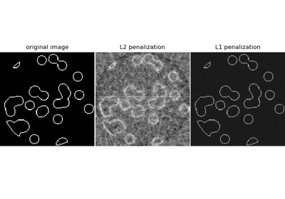

Compressive sensing: tomography reconstruction with L1 prior (Lasso)

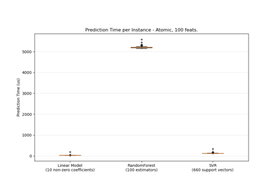

Prediction Latency

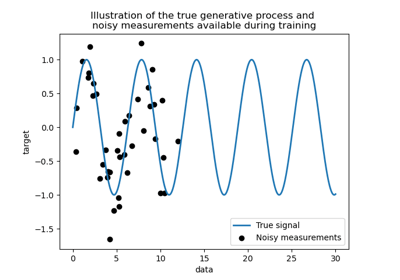

Comparison of kernel ridge and Gaussian process regression

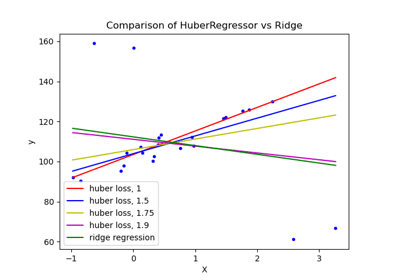

HuberRegressor vs Ridge on dataset with strong outliers

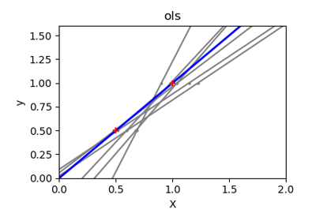

Ordinary Least Squares and Ridge Regression Variance

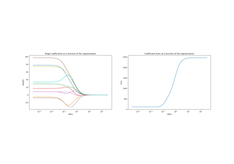

Plot Ridge coefficients as a function of the L2 regularization

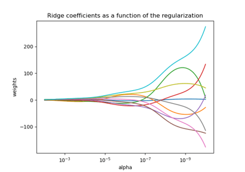

Plot Ridge coefficients as a function of the regularization

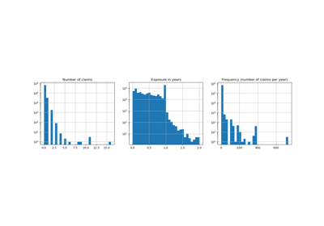

Poisson regression and non-normal loss

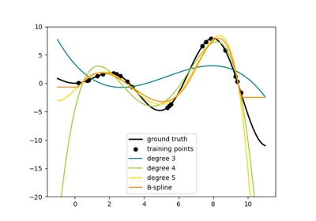

Polynomial and Spline interpolation

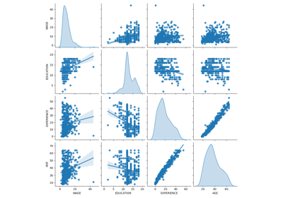

Common pitfalls in the interpretation of coefficients of linear models

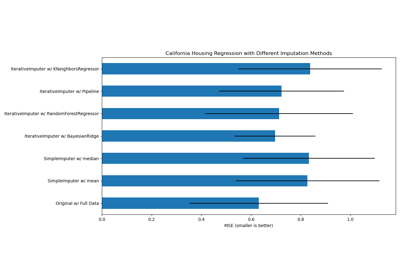

Imputing missing values with variants of IterativeImputer